# Cleaning data, variable distribution, and feature selection

Alisha Gumber

10/6/2019

## Predict stage of liver disease in Egyptian Hepatitis C patients using non-invasive strategies.

Diagnosis of liver disease requires taking a biopsy of the liver, which is an invasive procedure where a needle is inserted into a patient’s liver to collect a tissue sample. I am using the Hepatitis C dataset from the UCI Machine Learning Repository to predict the stage of liver fibrosis in Egyptian patients with Hepatitis C. The stages are measured by an F scale of F1-F4, corresponding to portal fibrosis, few septa, many septa, and cirrhosis. I want to see if it’s possible to predict severe (F3 and F4) or not severe (F1 and F2) liver disease stage using only a patient’s clinical data. The dataset contains basic demographic information, symptoms, blood panel results and RNA sequencing information. Since I want to use information that could be collected non-invasively, I will just be using the patients clinical data such as, demographic, symptomatic, and blood panel information as predictors. Originally there were 1,385 patient entries and 28 predictors. I did not want to impute missing data, so I decided to remove variables with a lot of missing data. After removing variables with a lot of missing data, (indicated with a 5), non-baseline information (4, 12, 24, 36, and 48 weeks ALS scores), and non-clinical data, I am left with 1,385 patients and 16 predictors. Predictors: Age, Gender, BMI, Fever, Nausea/Vomiting, Headache, Diarrhea, Fatigue/Body Ache, Jaundice, Epigastric pain, White blood cell count, red blood cell count, hemoglobin, platelet count, AST count (aspartate transaminase), and ALT (alanine transaminase). Predict: baseline histological stage 1-4 (not severe/severe).

Load necessary packages

Import csv file with data

```r
HCV_data <- read_csv("/Users/alishagumber/Desktop/Machine\ Learning/Hep_C_dataset/HCV-Egy-Data.csv")
View(HCV_data)
```

## Cleaning the data and feature selection

```r
# filter dataset for all variables I will be using (drop columns 17-27)
HCV_data <- HCV_data[-c(17:28)]
```

```r
# check for missing data
sum(is.na(HCV_data))
```

```
## [1] 0
```

```r
# rename some columns for easier analysis
colnames(HCV_data)[colnames(HCV_data)=="Fatigue & generalized bone ache"] <- "fatigue_and_bodyache"
colnames(HCV_data)[colnames(HCV_data)=="Epigastric pain"] <- "epigastric_pain"
colnames(HCV_data)[colnames(HCV_data)=="Baselinehistological staging" ] <- "baseline_histological_stage"
colnames(HCV_data)[colnames(HCV_data)=="AST 1" ] <- "AST_1"
colnames(HCV_data)[colnames(HCV_data)=="ALT 1" ] <- "ALT_1"
colnames(HCV_data)[colnames(HCV_data)=="Nausea/Vomting" ] <- "nausea_vomiting"
```

Since many models work best with binary responses, i’m converting the histological stage into a classification binary response, with either a diagnosis of severe (stages 3 and 4) or not severe (stage 1 and 2)

```r
# convert histological stage to binary response
Severe = ifelse(HCV_data$baseline_histological_stage>=3, "Severe", "Not Severe")
HCV_data = data.frame(HCV_data, Severe)

head(HCV_data)
```

```
##   Age Gender BMI Fever nausea_vomiting Headache Diarrhea fatigue_and_bodyache
## 1  56      1  35     2               1        1        1                    2
## 2  46      1  29     1               2        2        1                    2
## 3  57      1  33     2               2        2        2                    1
## 4  49      2  33     1               2        1        2                    1
## 5  59      1  32     1               1        2        1                    2
## 6  58      2  22     2               2        2        1                    2
##   Jaundice epigastric_pain   WBC     RBC HGB   Plat AST_1 ALT_1
## 1        2               2  7425 4248807  14 112132    99    84
## 2        2               1 12101 4429425  10 129367    91   123
## 3        1               1  4178 4621191  12 151522   113    49
## 4        2               1  6490 4794631  10 146457    43    64
## 5        2               2  3661 4606375  11 187684    99   104
## 6        2               1 11785 3882456  15 131228    66   104
##   baseline_histological_stage     Severe
## 1                           2 Not Severe
## 2                           2 Not Severe
## 3                           4     Severe
## 4                           3     Severe
## 5                           1 Not Severe
## 6                           4     Severe
```

```r
# convert categorical data (male/female and yes/no) to factors for better visualization of distribution. They are currently numeric

HCV_data[HCV_data$Gender == 1,]$Gender <- "M"
HCV_data[HCV_data$Gender == 2,]$Gender <- "F"
HCV_data$Gender <- as.factor(HCV_data$Gender)

HCV_data[HCV_data$Fever == 1,]$Fever <- "Yes"
HCV_data[HCV_data$Fever == 2,]$Fever <- "No"
HCV_data$Fever <- as.factor(HCV_data$Fever)

HCV_data[HCV_data$nausea_vomiting == 1,]$nausea_vomiting <- "Yes"
HCV_data[HCV_data$nausea_vomiting == 2,]$nausea_vomiting <- "No"
HCV_data$nausea_vomiting <- as.factor(HCV_data$nausea_vomiting)

HCV_data[HCV_data$Headache == 1,]$Headache <- "Yes"
HCV_data[HCV_data$Headache == 2,]$Headache <- "No"
HCV_data$Headache <- as.factor(HCV_data$Headache)

HCV_data[HCV_data$Diarrhea == 1,]$Diarrhea <- "Yes"
HCV_data[HCV_data$Diarrhea == 2,]$Diarrhea <- "No"
HCV_data$Diarrhea <- as.factor(HCV_data$Diarrhea)

HCV_data[HCV_data$fatigue_and_bodyache == 1,]$fatigue_and_bodyache <- "Yes"
HCV_data[HCV_data$fatigue_and_bodyache == 2,]$fatigue_and_bodyache <- "No"
HCV_data$fatigue_and_bodyache <- as.factor(HCV_data$fatigue_and_bodyache)

HCV_data[HCV_data$Jaundice == 1,]$Jaundice <- "Yes"
HCV_data[HCV_data$Jaundice == 2,]$Jaundice <- "No"
HCV_data$Jaundice <- as.factor(HCV_data$Jaundice)

HCV_data[HCV_data$epigastric_pain == 1,]$epigastric_pain <- "Yes"
HCV_data[HCV_data$epigastric_pain == 2,]$epigastric_pain <- "No"
HCV_data$epigastric_pain <- as.factor(HCV_data$epigastric_pain)

str(HCV_data)
```

```
## 'data.frame':    1385 obs. of  18 variables:
##  $ Age                        : num  56 46 57 49 59 58 42 48 44 45 ...
##  $ Gender                     : Factor w/ 2 levels "F","M": 2 2 2 1 2 1 1 1 2 2 ...
##  $ BMI                        : num  35 29 33 33 32 22 26 30 23 30 ...
##  $ Fever                      : Factor w/ 2 levels "No","Yes": 1 2 1 2 2 1 2 2 2 1 ...
##  $ nausea_vomiting            : Factor w/ 2 levels "No","Yes": 2 1 1 1 2 1 2 2 2 2 ...
##  $ Headache                   : Factor w/ 2 levels "No","Yes": 2 1 1 2 1 1 1 1 1 1 ...
##  $ Diarrhea                   : Factor w/ 2 levels "No","Yes": 2 2 1 1 2 2 1 1 1 1 ...
##  $ fatigue_and_bodyache       : Factor w/ 2 levels "No","Yes": 1 1 2 2 1 1 1 2 1 2 ...
##  $ Jaundice                   : Factor w/ 2 levels "No","Yes": 1 1 2 1 1 1 1 2 2 2 ...
##  $ epigastric_pain            : Factor w/ 2 levels "No","Yes": 1 2 2 2 1 2 1 1 1 1 ...
##  $ WBC                        : num  7425 12101 4178 6490 3661 ...
##  $ RBC                        : num  4248807 4429425 4621191 4794631 4606375 ...
##  $ HGB                        : num  14 10 12 10 11 15 12 11 12 12 ...
##  $ Plat                       : num  112132 129367 151522 146457 187684 ...
##  $ AST_1                      : num  99 91 113 43 99 66 78 119 93 55 ...
##  $ ALT_1                      : num  84 123 49 64 104 104 57 112 83 68 ...
##  $ baseline_histological_stage: num  2 2 4 3 1 4 4 3 2 2 ...
##  $ Severe                     : Factor w/ 2 levels "Not Severe","Severe": 1 1 2 2 1 2 2 2 1 1 ...
```

Continous Variables: Age, BMI, WBC, RBC, HGB, Plat, AST, and ALT

## Look at distribution of variables

```r
# convert fibrosis stage to categorial value so I can color them accordingly
HCV_data$baseline_histological_stage <- as.factor(HCV_data$baseline_histological_stage)
```

## Categorical variables:

Number of patients in dataset with each stage of liver fibrosis (F1-F4)

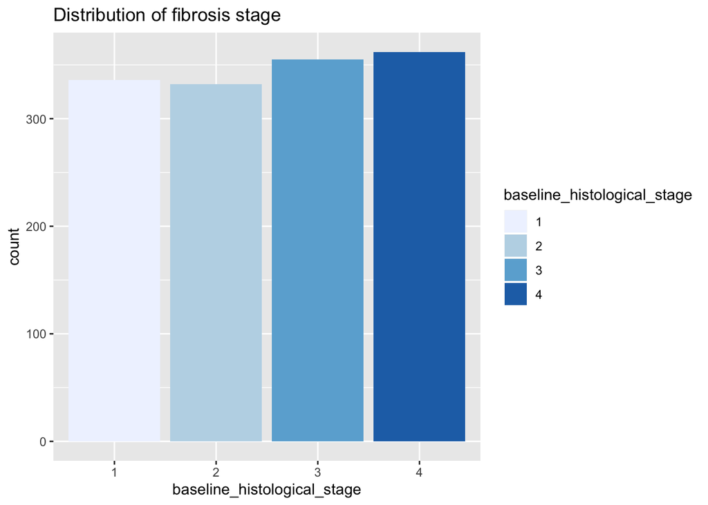

```r
# plot number of patients at each stage of fibrosis in barplot
ggplot(data = HCV_data) + ggtitle("Distribution of fibrosis stage") +
  geom_bar(mapping = aes(x = baseline_histological_stage, fill = baseline_histological_stage)) +
  scale_fill_brewer()
```

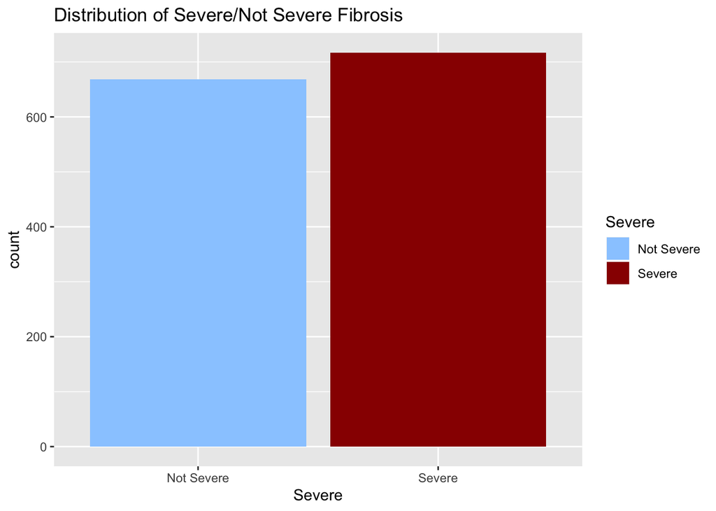

```r
# distribution of severe/not severe
ggplot(data = HCV_data) + ggtitle("Distribution of Severe/Not Severe Fibrosis") +
  geom_bar(mapping = aes(x = Severe, fill = Severe)) +
  scale_fill_manual(values=c("#99CCFF", "#990000"))
```

Gender distribution

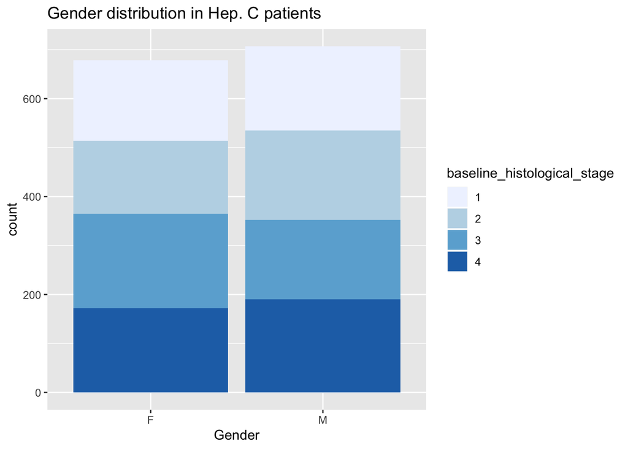

```r
# About the same number of men and women in study, a little more men
ggplot(data = HCV_data) + ggtitle("Gender distribution in Hep. C patients") +
  stat_count(mapping = aes(x = Gender, fill = baseline_histological_stage)) +
  scale_fill_brewer()
```

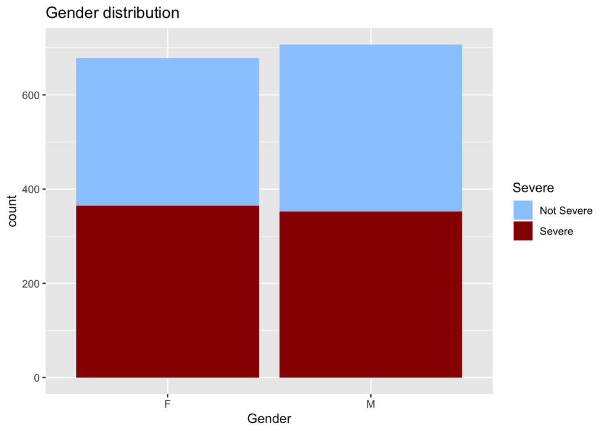

```r
# gender distribution of severe/not severe
ggplot(data = HCV_data) + ggtitle("Gender distribution") +
  stat_count(mapping = aes(x = Gender, fill = Severe)) +
  scale_fill_manual(values=c("#99CCFF", "#990000"))
```

Patients who developed fevers:

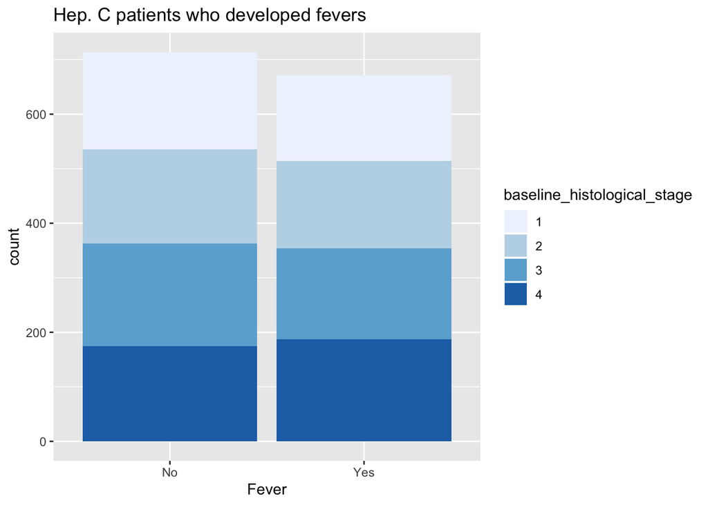

```r
# more patients did not develop a fever, but more stage 4 patients did develop of fever
ggplot(data = HCV_data) + ggtitle("Hep. C patients who developed fevers") +
  stat_count(mapping = aes(x = Fever, fill = baseline_histological_stage)) +
  scale_fill_brewer()
```

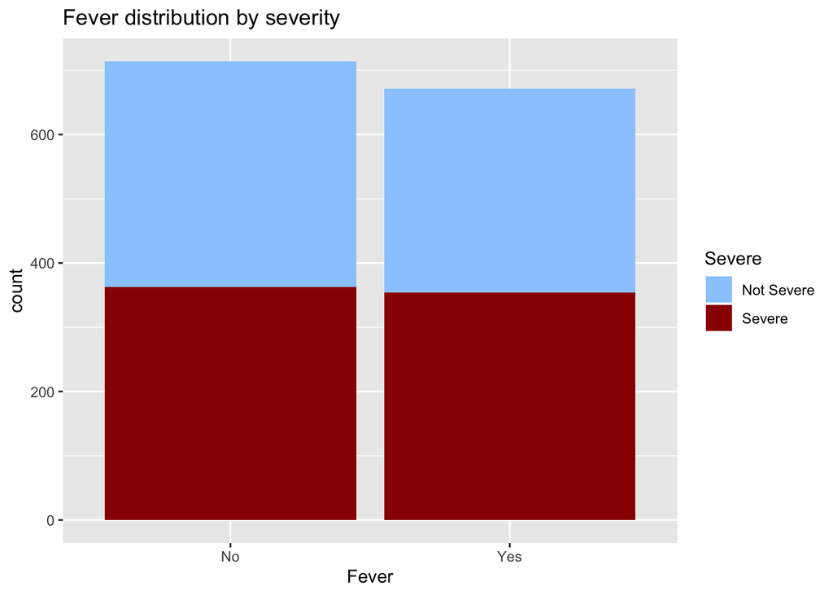

```r
# barplot distribution of patients who developed fevers by severity of fibrosis
ggplot(data = HCV_data) + ggtitle("Fever distribution by severity") +
  stat_count(mapping = aes(x = Fever, fill = Severe)) +
  scale_fill_manual(values=c("#99CCFF", "#990000"))
```

Patients who had headaches

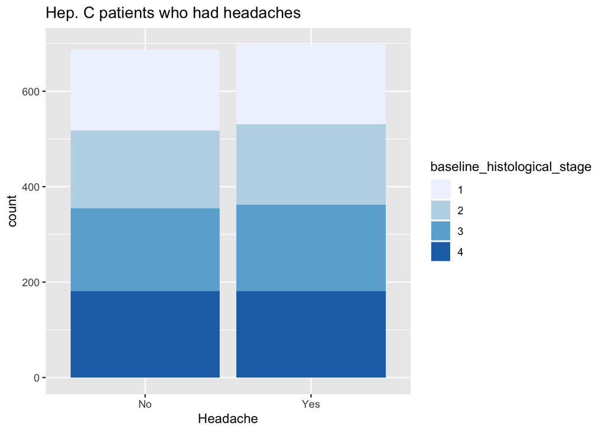

```r
ggplot(data = HCV_data) + ggtitle("Hep. C patients who had headaches") +
  stat_count(mapping = aes(x = Headache, fill = baseline_histological_stage)) +
  scale_fill_brewer()
```

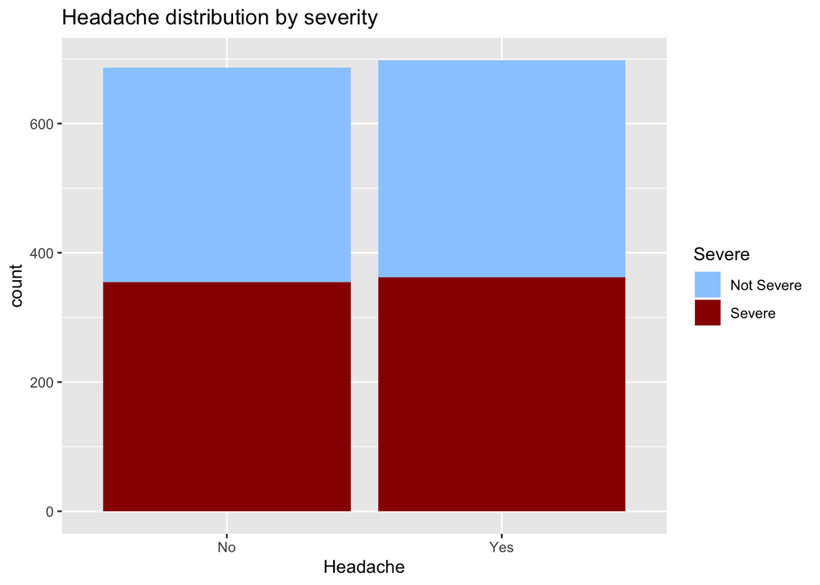

```r
ggplot(data = HCV_data) + ggtitle("Headache distribution by severity") +
  stat_count(mapping = aes(x = Headache, fill = Severe)) +
  scale_fill_manual(values=c("#99CCFF", "#990000"))
```

Patients who experienced diarrhea

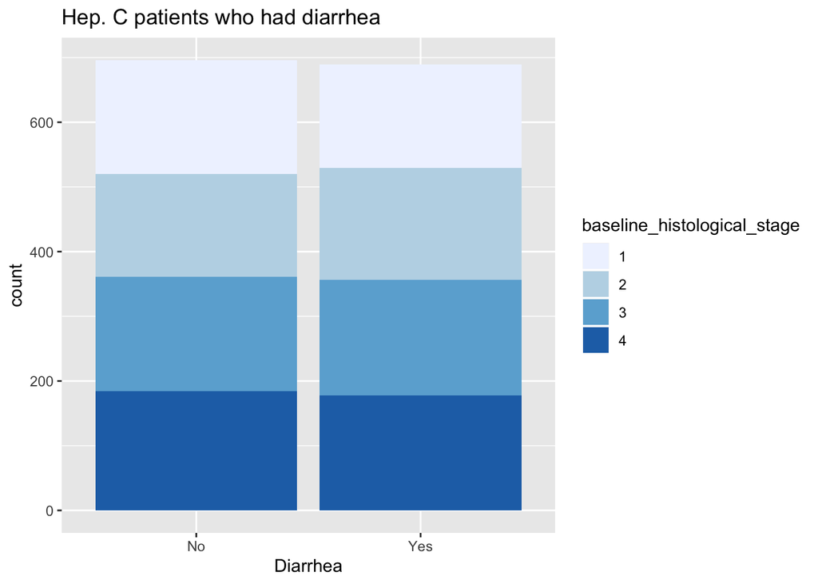

```r
ggplot(data = HCV_data) + ggtitle("Hep. C patients who had diarrhea") +
  stat_count(mapping = aes(x = Diarrhea, fill = baseline_histological_stage)) +
  scale_fill_brewer()
```

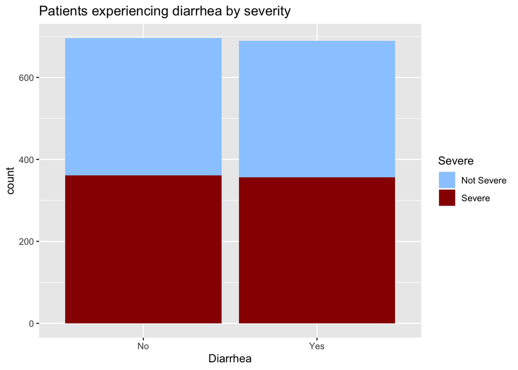

```r
ggplot(data = HCV_data) + ggtitle("Patients experiencing diarrhea by severity") +
  stat_count(mapping = aes(x = Diarrhea, fill = Severe)) +
  scale_fill_manual(values=c("#99CCFF", "#990000"))
```

Patients who experienced fatigue and bodyaches

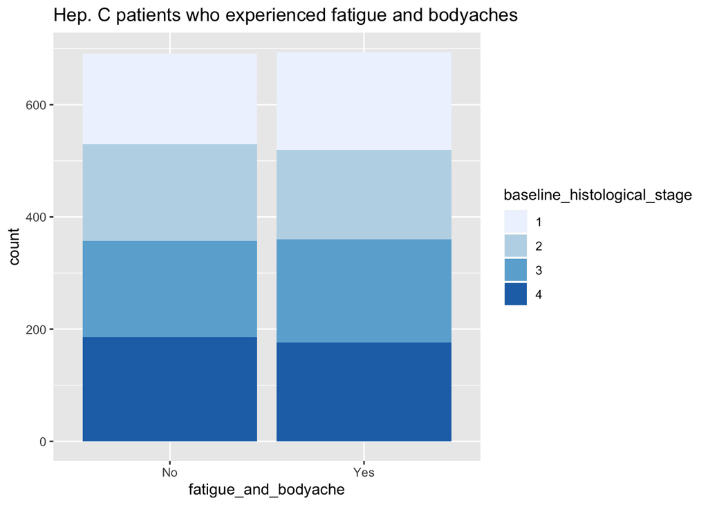

```r
ggplot(data = HCV_data) + ggtitle("Hep. C patients who experienced fatigue and bodyaches") +
  stat_count(mapping = aes(x = fatigue_and_bodyache, fill = baseline_histological_stage)) +
  scale_fill_brewer()
```

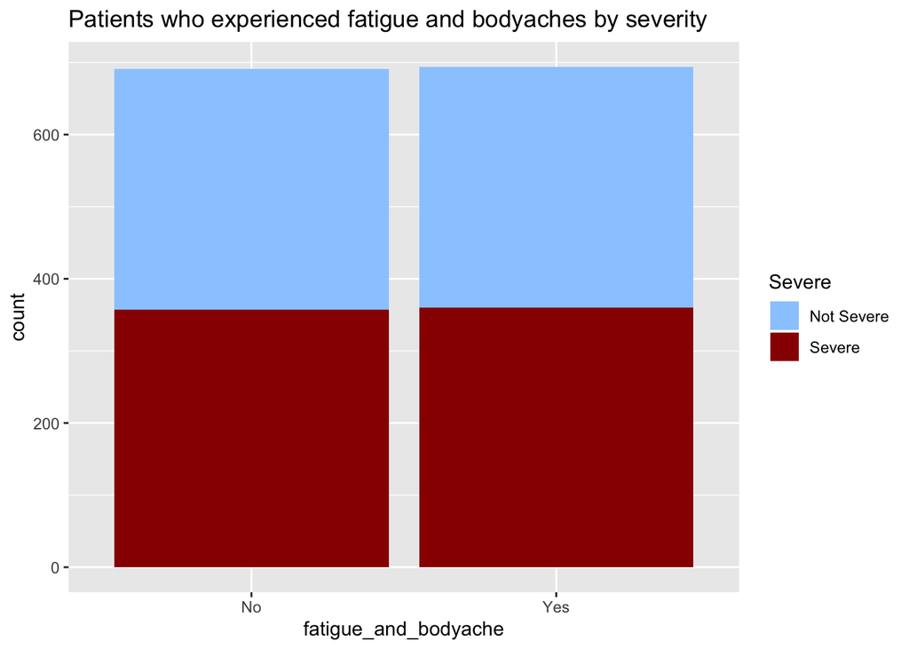

```r
ggplot(data = HCV_data) + ggtitle("Patients who experienced fatigue and bodyaches by severity") +
  stat_count(mapping = aes(x = fatigue_and_bodyache, fill = Severe)) +
  scale_fill_manual(values=c("#99CCFF", "#990000"))
```

Patients who developed Jaundice

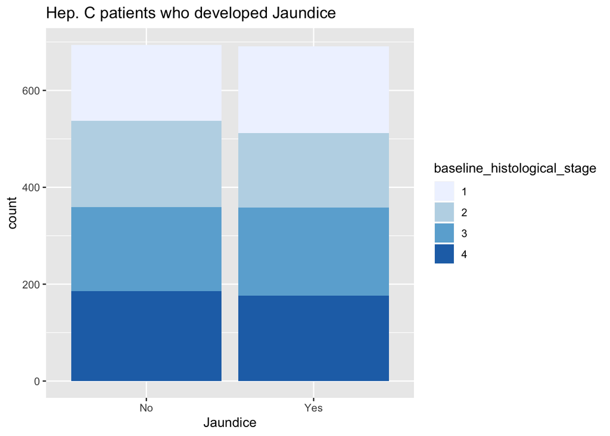

```r
# a little more stage 4 patients did not develop jaundice and more stage 1 patients did
ggplot(data = HCV_data) + ggtitle("Hep. C patients who developed Jaundice") +
  stat_count(mapping = aes(x = Jaundice, fill = baseline_histological_stage)) +
  scale_fill_brewer()
```

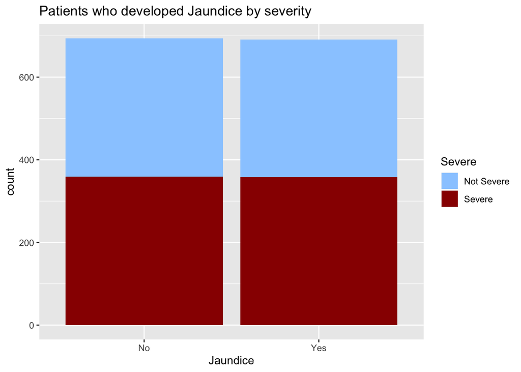

```r
ggplot(data = HCV_data) + ggtitle("Patients who developed Jaundice by severity") +
  stat_count(mapping = aes(x = Jaundice, fill = Severe)) +
  scale_fill_manual(values=c("#99CCFF", "#990000"))
```

Patients with epigastric pain

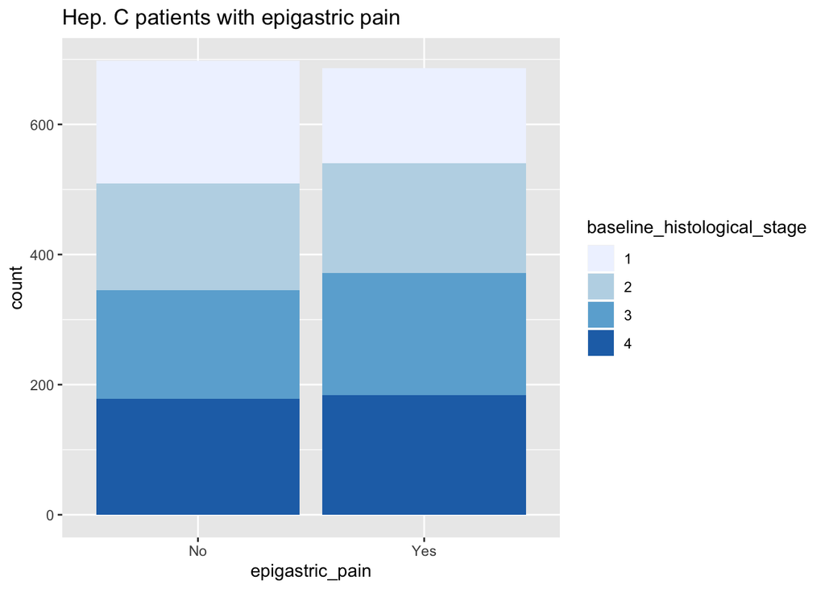

```r
# slightly more stage 3 and 4 patients with epigastric pain
ggplot(data = HCV_data) + ggtitle("Hep. C patients with epigastric pain") +
  stat_count(mapping = aes(x = epigastric_pain, fill = baseline_histological_stage)) +
  scale_fill_brewer()
```

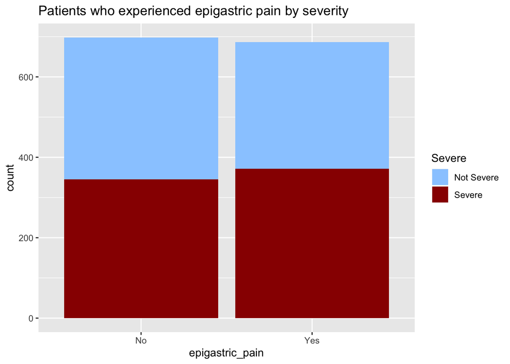

```r
ggplot(data = HCV_data) + ggtitle("Patients who experienced epigastric pain by severity") +
  stat_count(mapping = aes(x = epigastric_pain, fill = Severe)) +
  scale_fill_manual(values=c("#99CCFF", "#990000"))
```

## Numerical variables:

Distribution of Age

```r
age <- ggplot(data = HCV_data, aes(x = Age, fill = baseline_histological_stage)) +
  geom_histogram(position="identity", alpha=0.5, bins= 30) +
  scale_fill_brewer()
```

Distribution of BMI

```r
bmi <- ggplot(data = HCV_data, aes(x = BMI, fill = baseline_histological_stage)) +
  geom_histogram(position="identity", alpha=0.5, bins= 30) +
  scale_fill_brewer()
```

Distribution of patients WBC

```r
# look at distribution of white blood cell count, color by stage of fibrosis
# patients with cirhosis have lower WBC. Normal considered 4,500-11,000
wbc_count <- ggplot(data = HCV_data, aes(x = WBC, fill = baseline_histological_stage)) +
  geom_histogram(position="identity", alpha=0.5, bins= 30) +
  scale_fill_brewer()
```

Hemoglobin (HGB) levels:

```r
# normal HGB levels for women: 12.0-15.5, normal for men: 13.5-17.5
# low HGB levels sometimes occur in patients with hep. c
hgb <- ggplot(data = HCV_data, aes(x = HGB, fill = baseline_histological_stage)) +
  geom_histogram(alpha=0.5, bins= 25) +
  scale_fill_brewer()
```

AST (aspartate aminotransferase) levels

```r
ast <- ggplot(data = HCV_data, aes(x = AST_1, fill = baseline_histological_stage)) +
  geom_histogram(position="identity", alpha=0.5, bins= 30) +
  scale_fill_brewer()
```

ALT (alanine aminotransferase) levels

```r
alt <- ggplot(data = HCV_data, aes(x = ALT_1, fill = baseline_histological_stage)) +
  geom_histogram(position="identity", alpha=0.5, bins= 30) +
  scale_fill_brewer()
```

View distribution of continous variables

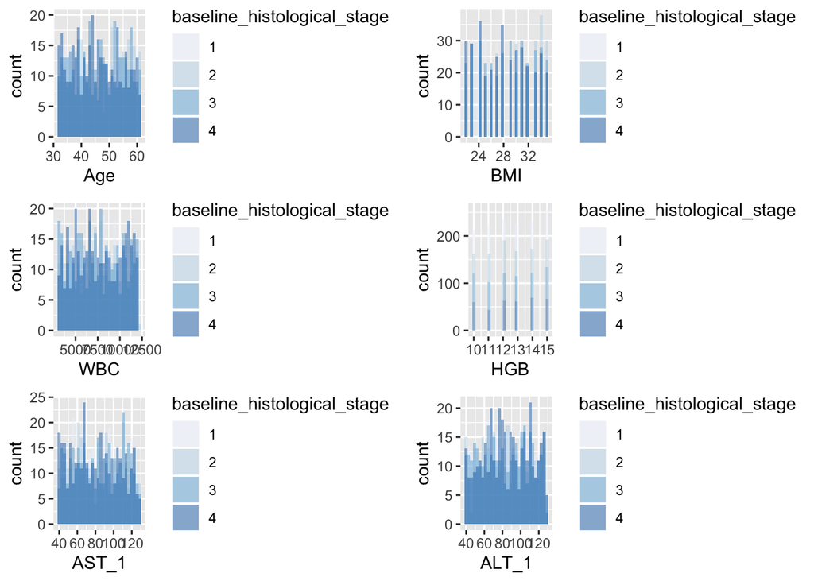

```r
grid.arrange(age, bmi, wbc_count, hgb, ast, alt)
```

**The variables are not normally distributed.**

## Run Shapiro-Wilk’s test to check for normality among variables.

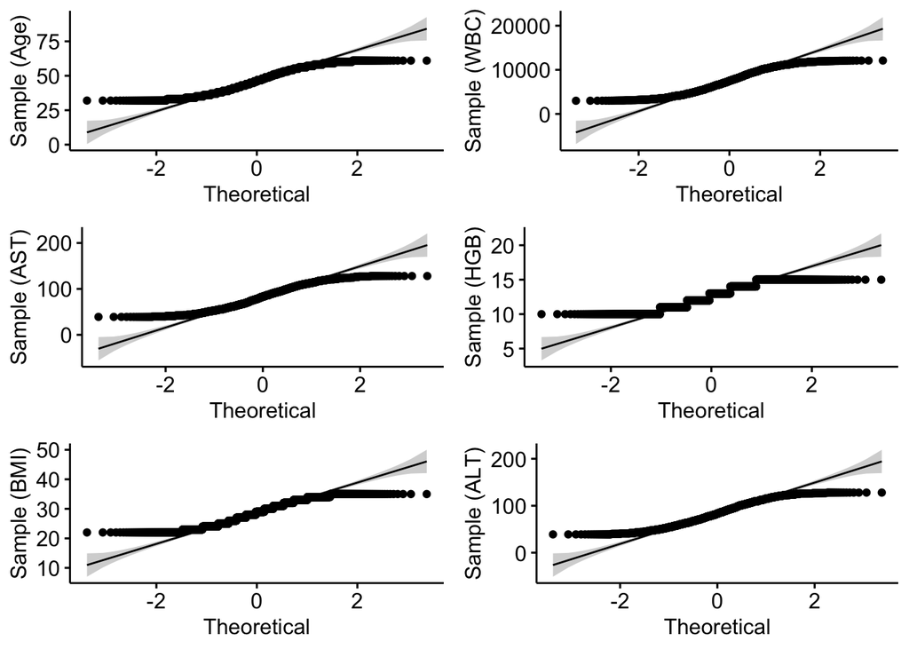

```r
## qqplots draw correlation between a given sample and a normal distribution
age_qq <- ggqqplot(HCV_data$Age, ylab = "Sample (Age)")
wbc_qq <- ggqqplot(HCV_data$WBC, ylab = "Sample (WBC)")
ast_qq <- ggqqplot(HCV_data$AST_1, ylab = "Sample (AST)")
bmi_qq <- ggqqplot(HCV_data$BMI, ylab = "Sample (BMI)")
hgb_qq <- ggqqplot(HCV_data$HGB, ylab = "Sample (HGB)")
alt_qq <- ggqqplot(HCV_data$ALT_1, ylab = "Sample (ALT)")

grid.arrange(age_qq, wbc_qq, ast_qq, hgb_qq, bmi_qq, alt_qq)
```

```r
# Run Shapiro-Wilk's test to test for normalist among variables
shapiro.test(HCV_data$Age)
```

```
##
##  Shapiro-Wilk normality test
##
## data:  HCV_data$Age
## W = 0.94691, p-value < 2.2e-16
```

```r
shapiro.test(HCV_data$WBC)
```

```
##
##  Shapiro-Wilk normality test
##
## data:  HCV_data$WBC
## W = 0.95198, p-value < 2.2e-16
```

```r
shapiro.test(HCV_data$AST_1)
```

```
##
##  Shapiro-Wilk normality test
##
## data:  HCV_data$AST_1
## W = 0.95403, p-value < 2.2e-16
```

```r
shapiro.test(HCV_data$BMI)
```

```
##
##  Shapiro-Wilk normality test
##
## data:  HCV_data$BMI
## W = 0.94013, p-value < 2.2e-16
```

```r
shapiro.test(HCV_data$HGB)
```

```
##
##  Shapiro-Wilk normality test
##
## data:  HCV_data$HGB
## W = 0.90481, p-value < 2.2e-16
```

```r
shapiro.test(HCV_data$ALT_1)
```

```
##
##  Shapiro-Wilk normality test
##
## data:  HCV_data$ALT_1
## W = 0.95712, p-value < 2.2e-16
```

```r
# From the output, the p-value < 0.05 implying that the distribution of the data is significantly different from normal distribution. We cannot assume normality.
```

## Feature Selection with backward elimination

```r
# backward elimination
# convert factors in diabetes column to numeric
HCV_data$Severe <- ifelse(HCV_data$Severe  == "Severe", 1 , 2)
HCV_data$Severe <- as.numeric(as.character(HCV_data$Severe))

model_back_el <- lm(Severe ~ Age + Gender + BMI + Fever + nausea_vomiting + Headache + Diarrhea + fatigue_and_bodyache + Jaundice + epigastric_pain + WBC + RBC + HGB + Plat + AST_1 + ALT_1, data = HCV_data)
summary(model_back_el)
```

```
##
## Call:
## lm(formula = Severe ~ Age + Gender + BMI + Fever + nausea_vomiting +
##     Headache + Diarrhea + fatigue_and_bodyache + Jaundice + epigastric_pain +
##     WBC + RBC + HGB + Plat + AST_1 + ALT_1, data = HCV_data)
##
## Residuals:
##     Min      1Q  Median      3Q     Max
## -0.6616 -0.4784 -0.3693  0.5102  0.7021
##
## Coefficients:
##                           Estimate Std. Error t value Pr(>|t|)
## (Intercept)              1.085e+00  2.437e-01   4.451 9.26e-06 ***
## Age                      1.483e-03  1.531e-03   0.969  0.33283
## GenderM                  4.173e-02  2.692e-02   1.550  0.12135
## BMI                      9.023e-03  3.312e-03   2.725  0.00652 **
## FeverYes                -2.298e-02  2.690e-02  -0.854  0.39314
## nausea_vomitingYes       6.037e-02  2.704e-02   2.232  0.02574 *
## HeadacheYes             -1.594e-03  2.693e-02  -0.059  0.95280
## DiarrheaYes             -8.710e-04  2.701e-02  -0.032  0.97428
## fatigue_and_bodyacheYes -6.749e-04  2.691e-02  -0.025  0.97999
## JaundiceYes             -8.808e-03  2.695e-02  -0.327  0.74384
## epigastric_painYes      -4.569e-02  2.701e-02  -1.691  0.09099 .
## WBC                     -2.530e-06  5.052e-06  -0.501  0.61658
## RBC                      9.815e-09  3.885e-08   0.253  0.80060
## HGB                     -6.169e-04  7.870e-03  -0.078  0.93754
## Plat                     3.946e-07  3.485e-07   1.132  0.25765
## AST_1                    2.647e-04  5.176e-04   0.511  0.60919
## ALT_1                   -4.957e-04  5.219e-04  -0.950  0.34235
## ---
## Signif. codes:  0 '***' 0.001 '**' 0.01 '*' 0.05 '.' 0.1 ' ' 1
##
## Residual standard error: 0.4989 on 1368 degrees of freedom
## Multiple R-squared:  0.01526,    Adjusted R-squared:  0.003743
## F-statistic: 1.325 on 16 and 1368 DF,  p-value: 0.173
```

```r
step(model_back_el, direction = "backward")
```

```
## Start:  AIC=-1909.05
## Severe ~ Age + Gender + BMI + Fever + nausea_vomiting + Headache +
##     Diarrhea + fatigue_and_bodyache + Jaundice + epigastric_pain +
##     WBC + RBC + HGB + Plat + AST_1 + ALT_1
##
##                        Df Sum of Sq    RSS     AIC
## - fatigue_and_bodyache  1   0.00016 340.54 -1911.0
## - Diarrhea              1   0.00026 340.54 -1911.0
## - Headache              1   0.00087 340.54 -1911.0
## - HGB                   1   0.00153 340.54 -1911.0
## - RBC                   1   0.01589 340.56 -1911.0
## - Jaundice              1   0.02659 340.57 -1910.9
## - WBC                   1   0.06244 340.60 -1910.8
## - AST_1                 1   0.06509 340.60 -1910.8
## - Fever                 1   0.18164 340.72 -1910.3
## - ALT_1                 1   0.22460 340.76 -1910.1
## - Age                   1   0.23363 340.77 -1910.1
## - Plat                  1   0.31923 340.86 -1909.8
## <none>                              340.54 -1909.0
## - Gender                1   0.59813 341.14 -1908.6
## - epigastric_pain       1   0.71216 341.25 -1908.2
## - nausea_vomiting       1   1.24069 341.78 -1906.0
## - BMI                   1   1.84814 342.39 -1903.5
##
## Step:  AIC=-1911.05
## Severe ~ Age + Gender + BMI + Fever + nausea_vomiting + Headache +
##     Diarrhea + Jaundice + epigastric_pain + WBC + RBC + HGB +
##     Plat + AST_1 + ALT_1
##
##                   Df Sum of Sq    RSS     AIC
## - Diarrhea         1   0.00025 340.54 -1913.0
## - Headache         1   0.00086 340.54 -1913.0
## - HGB              1   0.00153 340.54 -1913.0
## - RBC              1   0.01583 340.56 -1913.0
## - Jaundice         1   0.02663 340.57 -1912.9
## - WBC              1   0.06258 340.60 -1912.8
## - AST_1            1   0.06528 340.60 -1912.8
## - Fever            1   0.18158 340.72 -1912.3
## - ALT_1            1   0.22462 340.76 -1912.1
## - Age              1   0.23357 340.77 -1912.1
```

[output cut: 166 more lines]

```
## <none>                         341.31 -1927.9
## - Gender           1   0.62844 341.93 -1927.4
## - epigastric_pain  1   0.66284 341.97 -1927.2
## - nausea_vomiting  1   1.31607 342.62 -1924.6
## - BMI              1   1.71228 343.02 -1923.0
##
## Step:  AIC=-1928.74
## Severe ~ Gender + BMI + nausea_vomiting + epigastric_pain
##
##                   Df Sum of Sq    RSS     AIC
## <none>                         341.60 -1928.7
## - Gender           1    0.6105 342.21 -1928.3
## - epigastric_pain  1    0.6241 342.22 -1928.2
## - nausea_vomiting  1    1.2215 342.82 -1925.8
## - BMI              1    1.7075 343.31 -1923.8
```

```
##
## Call:
## lm(formula = Severe ~ Gender + BMI + nausea_vomiting + epigastric_pain,
##     data = HCV_data)
##
## Coefficients:
##        (Intercept)             GenderM                 BMI  nausea_vomitingYes
##           1.205793            0.042044            0.008618            0.059520
## epigastric_painYes
##          -0.042530
```